# Problemas de Localização

# Introdução

O problema de Localização de Instalações faz parte da classe de problemas de Programação Linear Inteira Mista (PLIM), conhecidos como **Location/Allocation Problems**.

Com aplicação nas diversas áreas do conhecimento, esta página dedica-se às aplicações em instalações de serviços públicos de saúde.

#P-centro

Dados: • I: Conjunto de pontos de demanda.

• J: Conjunto de pontos em potencial para localização dos centros.

• p: Número fixo de centros a serem localizados.

• dij : Distância entre o ponto de demanda i ∈ I e o ponto potencial de centro j ∈ J.

Variáveis de Decisão:

• yj : Variável binária que indica se um centro é localizado no ponto j ∈ J (1 se o centro é localizado, 0 caso contrário).

• xij : Variável binária que indica se a instalação i é escolhida como um centro. xij = 1 se a instalação i for selecionada, xij = 0 caso contrário.

• z: Maior distância entre um ponto de demanda e seu centro mais próximo. Função Objetivo:

## Modelo Matemático

O modelo pode ser descrito da seguinte forma:

$$\begin{aligned}
\text{Minimizar} \quad & w = d_{\max} \\
\text{Sujeito a:} \quad & \sum_{j} Y_{ij} = 1, \quad i = 1,2, \dots,
n \quad (1) \\
& \sum_{j} X_j = p, \quad i = 1,2, \dots, n \quad (2) \\
& Y_{ij} \leq X_j, \quad \text{Para todo } i \text{ e } j \quad (3)
\\
& w \geq \sum_{j} d_{ij} Y_{ij} \quad (4) \\
& X_j \in \{0,1\} \quad (5) \\
& Y_{ij} \in \{0,1\} \quad (6)
\end{aligned}$$

```r
bairros <- read_neighborhood(year = 2022)
```

```
## Using year/date 2022
```

```r
bairros_itacoatiara <- bairros[bairros$code_muni == 1301902, ]

if (nrow(bairros_itacoatiara) == 0) {
  stop("Não foram encontrados bairros para Itacoatiara-AM")
}
```

```r
coords <- st_centroid(bairros_itacoatiara$geom)
coords_matrix <- st_coordinates(coords) # Converter para matriz numérica

dist_matrix <- as.matrix(dist(coords_matrix))

# Parâmetros do problema
p <- 5  # Número de postos
n <- nrow(bairros_itacoatiara)  # Número de bairros

# Introduzir variável para a distância máxima (C)
# C será a distância máxima de qualquer bairro até o posto mais próximo
# Variável C é a que queremos minimizar

obj <- c(rep(0, n * n), rep(1, n))

#0 para as variáveis Xij(bairro é atendido?) porque não influenciam diretamente na distancia max
#1 para a variável C

# Restrições de atendimento:
#Cada bairro deve ser atendido por pelo menos um posto
A1 <- matrix(0, n, n * n + n)
for (i in 1:n) {
  A1[i, ((i - 1) * n + 1):(i * n)] <- 1
}
b1 <- rep(1, n)

# Restrições de cobertura: Um bairro só pode atender outro se for um posto
A2 <- matrix(0, n * n, n * n + n)
for (i in 1:n) {
  for (j in 1:n) {
    idx <- (i - 1) * n + j
    A2[idx, idx] <- 1
    A2[idx, n * n + j] <- -1
  }
}
b2 <- rep(0, n * n)

# Restrições para limitar a distância máxima (C)
A3 <- matrix(0, n * n, n * n + n)
for (i in 1:n) {
  for (j in 1:n) {
    idx <- (i - 1) * n + j
    A3[idx, idx] <- 1
    A3[idx, n * n + j] <- -1
  }
}
b3 <- rep(0, n * n)

# Restrição: Exatamente p postos devem ser instalados
A4 <- matrix(0, 1, n * n + n)
A4[1, (n * n + 1):(n * n + n)] <- 1
b4 <- p

# Combina todas as restrições
A <- rbind(A1, A2, A3, A4)
dir <- c(rep("=", n), rep("<=", n * n), rep("<=", n * n), "=")
b <- c(b1, b2, b3, b4)
```

```
## Solução encontrada!
## Os postos devem ser instalados nos bairros com os seguintes IDs:
## [1] "Araújo Costa" "Centenário"   "Centro"       "Colônia"      "Da Paz"
```

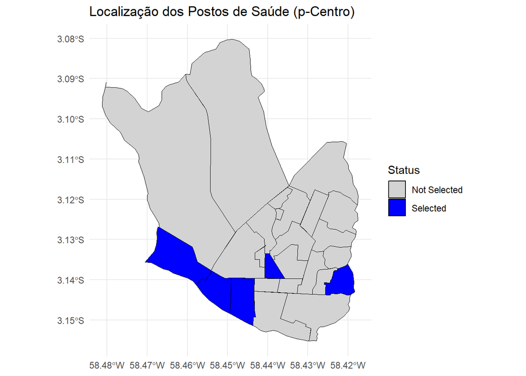

```r
resultado <- lp("min", obj, A, dir, b, all.bin = TRUE)

# Verificar o status da solução
if (resultado$status == 0) {
  cat("Solução encontrada!\n")
  # Extrair resultados
  solucao <- resultado$solution
  y <- solucao[(n * n + 1):(n * n + n)]  # Variáveis y_j
  postos_selecionados <- which(y == 1)
  bairros_selecionados <- bairros_itacoatiara$name_neighborhood[postos_selecionados]
  cat("Os postos devem ser instalados nos bairros com os seguintes IDs:\n")
  print(bairros_selecionados)

  # Adicionar uma coluna para indicar se o bairro foi selecionado
  bairros_itacoatiara$selected <- ifelse(1:nrow(bairros_itacoatiara) %in% postos_selecionados, "Selected", "Not Selected")

  # Plotar o resultado
  ggplot() +
    geom_sf(data = bairros_itacoatiara, aes(fill = selected), color = "black") +
    scale_fill_manual(values = c("Selected" = "blue", "Not Selected" = "lightgrey")) +
    labs(title = "Localização dos Postos de Saúde (p-Centro)",
         fill = "Status") +
    theme_minimal()

} else {
  cat("Não foi possível encontrar uma solução.\n")
}
```

#P-mediana

$$\tiny
\text{Minimizar} \quad \sum_{i \in I} \sum_{j \in J} d_{ij} x_{ij}$$

Sujeito a:

$$\tiny
\sum_{j \in J} x_{ij} = 1 \quad \forall i \in I$$

$$\tiny
x_{ij} \leq y_j \quad \forall i \in I, j \in J$$

$$\tiny
\sum_{j \in J} y_j = p$$

$$\tiny
x_{ij}, y_j \in \{0,1\}$$

1. Váriaveis de Decisão

• xij : Variável binária que indica se a instalação i é escolhida como uma mediana. xij = 1 se a instalação i for selecionada, xij = 0 caso contrário.

• yij : Variável binária que indica se a demanda no ponto j é atendida pela instalação i. yij = 1 se a demanda j for atendida pelo centro i, yij = 0 caso contrário.

2. Parâmetros

• I: Conjunto de locais dos clientes, onde i ∈ I.

• J: Conjunto de locais candidatos para instala¸c˜ao das medianas, onde j ∈ J.

• dij : Distância entre o cliente i e o local j.

Função Objetivo

Busca minimizar a soma ponderada das distâncias entre os pontos de demanda e os centros

3. Restrições

Cada cliente deve ser atendido por exatamente um local

Um cliente s´o pode ser atendido por um local com uma mediana instalada

Exatamente p medianas devem ser instaladas

```r
library(lpSolve)
library(geobr)
library(sf)

# Carregar os dados dos bairros de Itacoatiara, Amazonas
bairros <- read_neighborhood(year = 2022) # Carrega todos os bairros do Brasil
```

```
## Using year/date 2022
```

```
## Solução encontrada
## Os postos devem ser instalados nos seguintes bairros:
## [1] "Jardim Lorena" "Santa Luzia"   "São Francisco"
```

[figure not shown]

```r
bairros_itacoatiara <- bairros[bairros$code_muni == 1301902, ] # Filtro para Itacoatiara-AM

# Verificar se os dados foram carregados corretamente
if (nrow(bairros_itacoatiara) == 0) {
  stop("Não foram encontrados bairros para Itacoatiara-AM no geobr.")
}

# Obter os centróides dos bairros
coords <- st_centroid(bairros_itacoatiara$geom)
coords_matrix <- st_coordinates(coords) # Converter para matriz numérica

# Criar matriz de distâncias euclidianas
dist_matrix <- as.matrix(dist(coords_matrix))

p <- 3  # Número de postos a instalar
n <- nrow(bairros_itacoatiara)  # Número de bairros

obj <- c(as.vector(dist_matrix), rep(0, n))

# Restrições de atendimento
A1 <- matrix(0, n, n * n + n)
for (i in 1:n) {
  A1[i, ((i - 1) * n + 1):(i * n)] <- 1
}
b1 <- rep(1, n)

# Restrições de cobertura
A2 <- matrix(0, n * n, n * n + n)
for (i in 1:n) {
  for (j in 1:n) {
    idx <- (i - 1) * n + j
    A2[idx, idx] <- 1
    A2[idx, n * n + j] <- -1
  }
}
b2 <- rep(0, n * n)

# Restrição: Exatamente p postos devem ser instalados
A3 <- matrix(0, 1, n * n + n)
A3[1, (n * n + 1):(n * n + n)] <- 1
b3 <- p

# Combina as restrições
A <- rbind(A1, A2, A3)
dir <- c(rep("=", n), rep("<=", n * n), "=")
b <- c(b1, b2, b3)

# Resolver o problema
resultado <- lp("min", obj, A, dir, b, all.bin = TRUE)

if (resultado$status == 0) {
  cat("Solução encontrada\n")
  solucao <- resultado$solution
  y <- solucao[(n * n + 1):(n * n + n)]
  postos_selecionados <- which(y == 1)
  bairros_selecionados <- bairros_itacoatiara$name_neighborhood[postos_selecionados]
  cat("Os postos devem ser instalados nos seguintes bairros:\n")
  print(bairros_selecionados)

  # Adicionar uma coluna para indicar se o bairro foi selecionado
  bairros_itacoatiara$selected <- ifelse(1:nrow(bairros_itacoatiara) %in% postos_selecionados, "Selected", "Not Selected")

  # Plotar o resultado
  ggplot() +
    geom_sf(data = bairros_itacoatiara, aes(fill = selected), color = "black") +
    scale_fill_manual(values = c("Selected" = "blue", "Not Selected" = "lightgrey")) +
    labs(title = "Localização dos Postos de Saúde (p-Centro)",
         fill = "Status") +
    theme_minimal()
} else {
  cat("Não foi possível encontrar uma solução possível\n")
}
```

#Cobertura de conjuntos

1 Dados do Problema • I: Conjunto de pontos de demanda (clientes), I = {1, 2, . . . , n}.

• J: Conjunto de pontos potenciais para localização dos centros, J = {1, 2, . . . , m}.

• p: Número fixo de centros a serem localizados.

• dij : Distância entre o ponto de demanda i ∈ I e o ponto potencial de centro j ∈ J.

• R: Distância máxima permitida para um cliente ser coberto por um centro.

2. Variáveis de Decisão

• yj : Variável binária que indica se um centro é localizado no ponto j ∈ J (1 se o centro é localizado,0 caso contrário).

• xij : Variável binária que indica se a demanda i ∈ I é atendida pelo centro localizado em j ∈ J (1 se atendido, 0 caso contrário).

3. Função Objetivo

4. Restrições do Modelo

O modelo de cobertura de conjuntos envolve as seguintes restrições:

Cobertura de clientes Cada cliente deve ser atendido por pelo menos um centro dentro da distância R

```r
library(lpSolve)
library(geobr)
library(sf)
library(units)
```

```
## Using year/date 2022
```

```
## Solução encontrada com sucesso!
## Os postos devem ser instalados nos bairros:
## [1] "Araújo Costa"
```

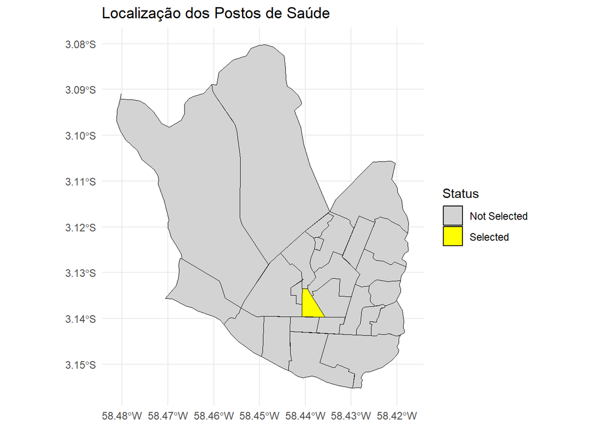

```r
library(ggplot2)

resolver_matrix_cobertura_conjuntos <- function(R_max_km) {
  bairros <- read_neighborhood(year = 2022)
  bairros_itacoatiara <- bairros[bairros$code_muni == 1301902, ]

  centroids <- st_centroid(bairros_itacoatiara)

  # Criar matriz de distâncias geodésicas (em km)
  dist_matrix <- st_distance(centroids, centroids)
  dist_matrix <- set_units(dist_matrix, "km")
  dist_matrix <- drop_units(dist_matrix)  # Remover unidades para cálculos

  # Criar matriz de cobertura (1 se está dentro do raio, 0 caso contrário)
  matrix_cobertura <- ifelse(dist_matrix <= R_max_km, 1, 0)

  n <- nrow(bairros_itacoatiara)
  var_decisao <- n

  # Função objetivo: minimizar o número de postos
  obj <- rep(1, var_decisao)

  # Restrição: cada bairro deve ser coberto por pelo menos um posto
  A <- matrix_cobertura
  b <- rep(1, n)  # Cada bairro deve ter pelo menos um posto
  dir <- rep(">=", n)  # Restrição da cobertura

  # Resolver o problema
  resultado <- lp("min", obj, A, dir, b, all.bin = TRUE)

  if (resultado$status == 0) {
    cat("Solução encontrada com sucesso!\n")
    solucao <- resultado$solution
    postos_selecionados <- which(solucao == 1)
    bairros_selecionados <- bairros_itacoatiara$name_neighborhood[postos_selecionados]
    cat("Os postos devem ser instalados nos bairros:\n")
    print(bairros_selecionados)

    bairros_itacoatiara$selected <- ifelse(1:nrow(bairros_itacoatiara) %in% postos_selecionados, "Selected", "Not Selected")

    ggplot() +
      geom_sf(data = bairros_itacoatiara, aes(fill = selected), color = "black") +
      scale_fill_manual(values = c("Selected" = "yellow", "Not Selected" = "lightgrey")) +
      labs(title = "Localização dos Postos de Saúde",
           fill = "Status") +
      theme_minimal()
  } else {
    cat("Não foi possível encontrar uma solução.\n")
  }
}

resolver_matrix_cobertura_conjuntos(5)
```